# BIOL 607 Homework 1

Nina McDonnell

9/18/2020

## Question 1

*Load quakes with data(quakes). Show what’s there with str() and summary().*

str() shows that the data frame includes 5 vectors. “lat,” “long,” and “mag” are numeric, whereas “depth” and “stations” are composed of integers. summary() provided descriptive statistics for each vector.

To learn more about the data set, I tried ?quakes. This function was particularly useful because it provided the units for vectors, which could not be discerned from the str or summary functions, as well as background information about the data. I also explored the data using View().

```r
data(quakes)
?quakes
str(quakes)
```

```
## 'data.frame':    1000 obs. of  5 variables:
##  $ lat     : num  -20.4 -20.6 -26 -18 -20.4 ...
##  $ long    : num  182 181 184 182 182 ...
##  $ depth   : int  562 650 42 626 649 195 82 194 211 622 ...
##  $ mag     : num  4.8 4.2 5.4 4.1 4 4 4.8 4.4 4.7 4.3 ...
##  $ stations: int  41 15 43 19 11 12 43 15 35 19 ...
```

```r
summary(quakes)
```

```
##       lat              long           depth            mag
##  Min.   :-38.59   Min.   :165.7   Min.   : 40.0   Min.   :4.00
##  1st Qu.:-23.47   1st Qu.:179.6   1st Qu.: 99.0   1st Qu.:4.30
##  Median :-20.30   Median :181.4   Median :247.0   Median :4.60
##  Mean   :-20.64   Mean   :179.5   Mean   :311.4   Mean   :4.62
##  3rd Qu.:-17.64   3rd Qu.:183.2   3rd Qu.:543.0   3rd Qu.:4.90
##  Max.   :-10.72   Max.   :188.1   Max.   :680.0   Max.   :6.40
##     stations
##  Min.   : 10.00
##  1st Qu.: 18.00
##  Median : 27.00
##  Mean   : 33.42
##  3rd Qu.: 42.00
##  Max.   :132.00
```

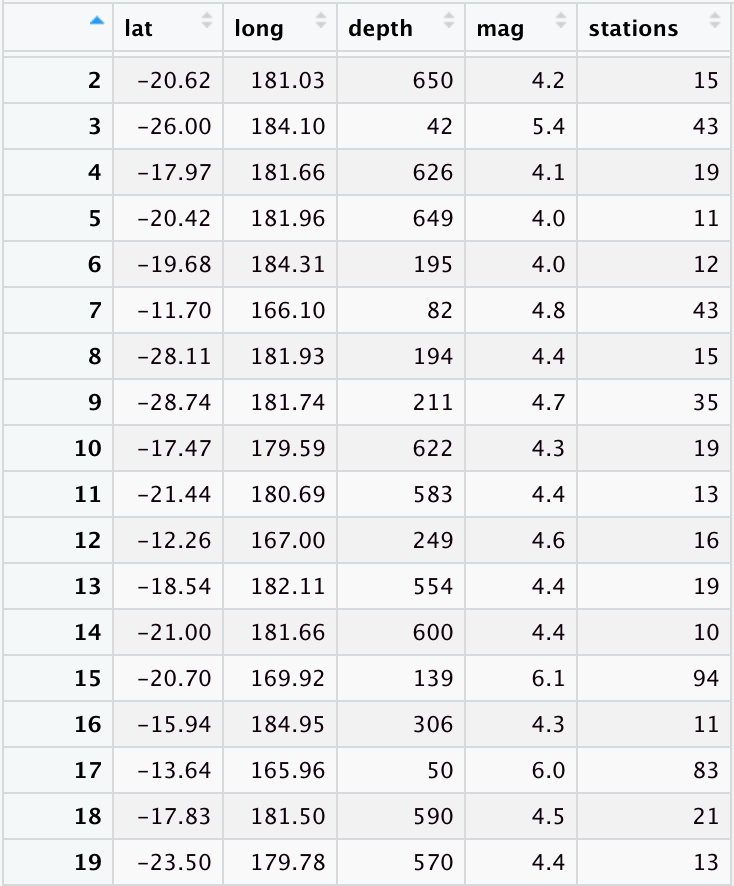

```r
View(quakes)
```

## Question 2

*Show the entirity of the column long.*

Showing the entirety of column “long”:

```r
quakes$long
```

```
##    [1] 181.62 181.03 184.10 181.66 181.96 184.31 166.10 181.93 181.74 179.59
##   [11] 180.69 167.00 182.11 181.66 169.92 184.95 165.96 181.50 179.78 180.31
##   [21] 181.16 166.32 180.16 182.00 180.28 181.49 167.51 180.79 181.47 182.37
##   [31] 179.24 166.74 185.05 180.80 186.00 179.33 169.23 181.28 181.40 169.33
##   [41] 176.78 186.10 179.82 186.04 169.41 182.30 181.70 166.32 180.08 185.25
##   [51] 182.35 184.42 173.20 180.67 182.16 182.13 181.00 180.60 181.35 179.20
##   [61] 181.55 182.40 172.38 166.22 181.41 184.93 181.60 179.62 181.86 187.81
##   [71] 185.80 184.35 166.20 179.99 181.23 180.04 184.70 167.06 181.71 181.11
##   [81] 180.21 180.99 182.38 183.40 181.70 184.31 170.50 179.96 186.30 186.44
##   [91] 167.53 167.06 182.02 169.71 185.26 182.40 181.11 183.41 166.54 179.92
##  [101] 185.61 178.41 180.39 181.60 180.69 183.50 180.60 169.49 185.90 177.81
##  [111] 185.23 182.31 182.45 178.30 178.35 178.31 172.23 172.29 167.40 169.48
##  [121] 166.97 178.90 180.40 182.43 180.60 167.89 183.84 178.57 181.70 183.51
##  [131] 185.43 181.22 168.98 180.30 180.82 168.02 187.32 182.80 182.60 184.16
##  [141] 169.46 181.40 167.10 181.43 173.50 184.40 185.17 173.49 180.17 181.50
```

[output cut: 85 more lines]

## Question 3

*Hey, another useful function - unique()! Apply it to a vector, and you can see what are all of the unique values. It’s great for really digging into a problematic vector. What unique stations are there? Use length() with unique() to determine how many stations there are.*

From “?quakes”, I can see that “stations” tells us the number of stations reporting. We cannot tell how many unique stations there are, since some may never have reported. However, from the max() function, we can see that there are at least 132– since that is the greatest number of stations that reported for any single seismic event.

```r
unique(quakes$stations)
```

```
##   [1]  41  15  43  19  11  12  35  13  16  10  94  83  21  18  17  22  57  79
##  [19]  25  30  42  34  32  23  26  27  24  73  31  61  40  45  91  14  75  60
##  [37]  65  38  64  54  33  29  76  28  39  67  52  69  59  68  46  63 106 122
##  [55]  20  37  98  90  50  47  62  71  74  36  66  85  48  55  72 104  56  49
##  [73]  80  82  53  58 105 123  95  89 112  93  51  44  87 100  92  81  70  86
##  [91] 118  78  99 129  88 109 119  77 132 115 121 110
```

```r
length(quakes$stations)
```

```
## [1] 1000
```

```r
max(quakes$stations)
```

```
## [1] 132
```

## Question 4

*Using range(), what is the range of depths where quakes occur?*

The range of depth at which earthquakes occurred is 40-680 km.

```r
range(quakes$depth)
```

```
## [1]  40 680
```

## E.C.

*Where was the earthquake of largest magnitude found? You’ll need to use come comparisons and the max() function for this in your indices instead of a number!*

**Approach** First, I used max(quakes$mag) to find that the largest magnitude earthquake had a value of 6.4 for “mag.” To identify the location of this event, I used the View() function to pull up a table, then searched the magnitude column for “6.4” to find the associated lat, long, and depth values.

The largest magnitude earthquake occurred at lat=-15.56, long=167.62, depth=127 km.

```r
max(quakes$mag)
```

```
## [1] 6.4
```

```r
View(quakes)
```

Filtered View() table:

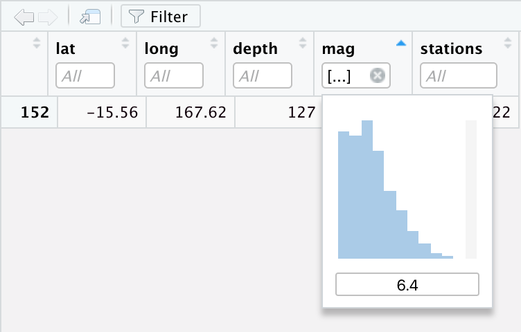

## **GitHub Repository**

https://github.com/ninamcdonnell/biol607_homework